# Modelo Continuo

Saul Arturo Ortiz Muñoz

2025-11-26

```r
library(cmdstanr)
source('./funciones.R')
```

- Se describen algunas alternativas para modelar cuando $n_{i}=0$, es decir, no se tienen observaciones en el dominio $i$.

# Alternativa (0): el modelo de Mamadou

- Se asume que
  $$y_{ij} = \boldsymbol{x_{ij}}^{T}\boldsymbol{\beta} + u_{i} + e_{ij}$$
  donde:
- $e_{ij}\sim SN(-\sigma_{e}\sqrt{2\rho_{e}^{2}/\pi}, \sigma^{2}_{e},\, \lambda_{e})$.
- $u_{i}\sim SN(-\sigma_{u}\sqrt{2\rho_{u}^{2}/\pi}, \sigma^{2}_{u},\, \lambda_{u})$.
- Además, $u_{i}$ es independiente de $e_{ij}$. Para hacer inferencia, usan máxima verosimilitud y recurren a la familia Closed Skew-Normal, una generalización de la distribución normal sesgada con cerradura bajo sumas de variables aleatorias CSN.
- Se asume que sólo existen dos parámetros de forma/correlación para toda la población: $\lambda_{e}$ y $\lambda_{u}$.
- $u_{i}$ se considera como un efecto aleatorio para cada región de estudio.
- ¿Será valido asignar este modelo para las observaciones faltantes?.
- ¿Qué pasa si hacemos que este sea nuestro modelo ahora?, ¿que sucede con el truncamiento oculto?: debemos conocer la distribución de la suma de dos normales sesgadas, la cuál se puede generalizar con la familia CSN

```r
model{
  for(i in 1:N_all){
    j = filter[i]
    if(j == 1){
      // observed y_{ij}
    } else{
      // missing y_{ij}
    }
  }
}
```

# Alternativa (1) pooling en mu

- Se propone usar
  $$\begin{align}
  \mu &\sim N_{M}(\mu_{0}1_{M}, \sigma^2_{\mu}I_{M}) \\
  \mu_{0} &\sim N(0, 10^2) \\
  \sigma^2_{\mu} &\sim InvGamma(0.001, 0.001),
  \end{align}$$

*Se observa que la estimación o efecto de cada $\mu_{i}$ es casi idéntico, por lo que quizás convenga hacer $M=1$, es decir, un único efecto.

```r
stan_code_pool <- '
data {
  int<lower=1> K;  // regions
  int<lower=0> N_obs; // no. of observed y_{ij}
  int<lower=0> N_mis; // no. of missing  y_{ij}
  array[N_obs] int<lower=1, upper=K> group; // region of observed
  array[N_mis] int<lower=1, upper=K> groupmis; // region of missing
  int<lower=1> p;  // predictors
  vector[N_obs] y_obs;
  matrix[N_obs, p] X_obs;
  matrix[N_mis, p] X_mis;
}
parameters {
  vector<lower=0, upper=1>[K] rho;
  real<lower=0> sigma;           // sd for all region
  //vector[K] mu;                // intercept for each region
  vector[K] mu_tilde;            // intercept for each region
  real mu0;                    // global mean for mu
  real<lower=0> sigma_mu;        // sd for mu
  vector[p] beta;                // Regression coefficients
  vector<lower=0>[K] z_tilde;    // Latent variable for each group
  vector[N_mis] y_mis;           // missing y_{ij}
}
transformed parameters{
  vector[K] mu = mu0 + sigma_mu .* mu_tilde;
  vector<lower=0>[K] z = z_tilde .* sigma ./ sqrt(1 - 2*square(rho)/pi());
}
model {
  target += sum( 0.5 * log1p(square(rho)) - log1m(square(rho)) );
  //lambda ~ normal(mu_lambda, sigma_lambda);
  //lambda_tilde ~ normal(0, 1);
  //mu_lambda ~ normal(0, 1);
  //sigma_lambda ~ normal(0, 1);
  sigma ~ inv_gamma(0.001, 0.001);
  //mu ~ normal(0, 10);
  mu_tilde ~ normal(0, 1);
  mu0 ~ normal(0, 10);
  sigma_mu ~ inv_gamma(0.001, 0.001);
  z_tilde ~ normal(0, 1);
  beta ~ normal(0, 10);
  vector[N_obs] sig = sigma * sqrt(1 - square(rho[group])) ./ sqrt(1 - 2/pi() * square(rho[group]));
  vector[N_obs] intercept = rho[group].* z[group] - sigma*rho[group] .* sqrt(2/pi()) ./ sqrt(1 - 2/pi() * square(rho[group]));
  target +=normal_id_glm_lupdf(y_obs | X_obs, mu[group] + intercept, beta, sig);
  vector[N_mis] sigmis = sigma * sqrt(1 - square(rho[groupmis]))./ sqrt(1 - 2/pi() * square(rho[groupmis]));
  vector[N_mis] interceptmis = rho[groupmis] .* z[groupmis]- sigma*rho[groupmis] .* sqrt(2/pi()) ./ sqrt(1 - 2/pi() * square(rho[groupmis]));
  target +=normal_id_glm_lupdf(y_mis | X_mis, mu[groupmis] + interceptmis, beta, sigmis);
}'
```

```r
stan_model_pool <- write_stan_file(stan_code_pool) # write .stan file
mod_pool <- cmdstan_model(stan_model_pool, compile=T)
```

## Preparar datos

- Se considera perder todas las observaciones de la región dos

```r
datos <- get_sim(out=c(2, 3), prop=0.5)
dat <- list(
  K = datos$K,
  N_obs = datos$N_obs, # observed
  N_mis = datos$N_mis, # missing
  p = datos$p,
  y_obs = datos$y_obs,
  X_obs =  datos$X_obs,
  X_mis =  datos$X_mis,
  group = datos$group,
  groupmis = datos$groupmis
)

tmp <- data.frame(y=datos$y_obs, datos$X_obs)
r1 <- lm(y~ . , data=tmp)

set.seed(2)
init_list <- list(
  beta = coef(r1)[-1],
  sigma=1,
  rho = c(0.5, 0.5, 0.5, 0.5),
  mu_tilde=c(0, 0, 0, 0),
  mu0 = 5,
  sigma_mu = 2,
  z_tilde=c(0.3, 0.3, 0.3, 0.3),
  y_mis = predict(r1, newdata = data.frame(datos$X_mis))
)
```

## Ajuste con VB

- Dejando que `eta`, un parámetro involucrado en el tamaño de paso en el ascenso del gradiente, sea buscado por `Stan`

```r
 apply(fit_vb$draws('rho'), 2, mean)
```

```
##    rho[1]    rho[2]    rho[3]    rho[4]
## 0.9999506 0.1545501 0.1597592 0.9997222
```

```r
datos$rho
```

```
## [1] 0.5 0.7 0.8 0.9
```

```r
apply(fit_vb$draws('mu'), 2, mean)
```

```
##    mu[1]    mu[2]    mu[3]    mu[4]
## 6.273431 6.275699 6.265585 6.273924
```

```r
datos$mu
```

```
## [1] 6.0 7.0 6.5 5.0
```

```r
apply(fit_vb$draws('sigma'), 2, mean)
```

```
##   sigma
## 98.6964
```

```r
sigma
```

```
## function (object, ...)
## UseMethod("sigma")
## <bytecode: 0x000002385510f828>
## <environment: namespace:stats>
```

```r
apply(fit_vb$draws('mu0'), 2, mean)
```

```
##      mu0
## 6.274389
```

```r
apply(fit_vb$draws('sigma_mu'), 2, mean)
```

```
##   sigma_mu
## 0.04259359
```

```r
apply(fit_vb$draws('beta'), 2, mean)
```

```
##     beta[1]     beta[2]     beta[3]     beta[4]     beta[5]
##  1.65988877  0.67823191 -1.46815817  0.09291246  0.04756991
```

```r
datos$b
```

```
## [1]  1.9  0.8 -1.4  0.0  0.0
```

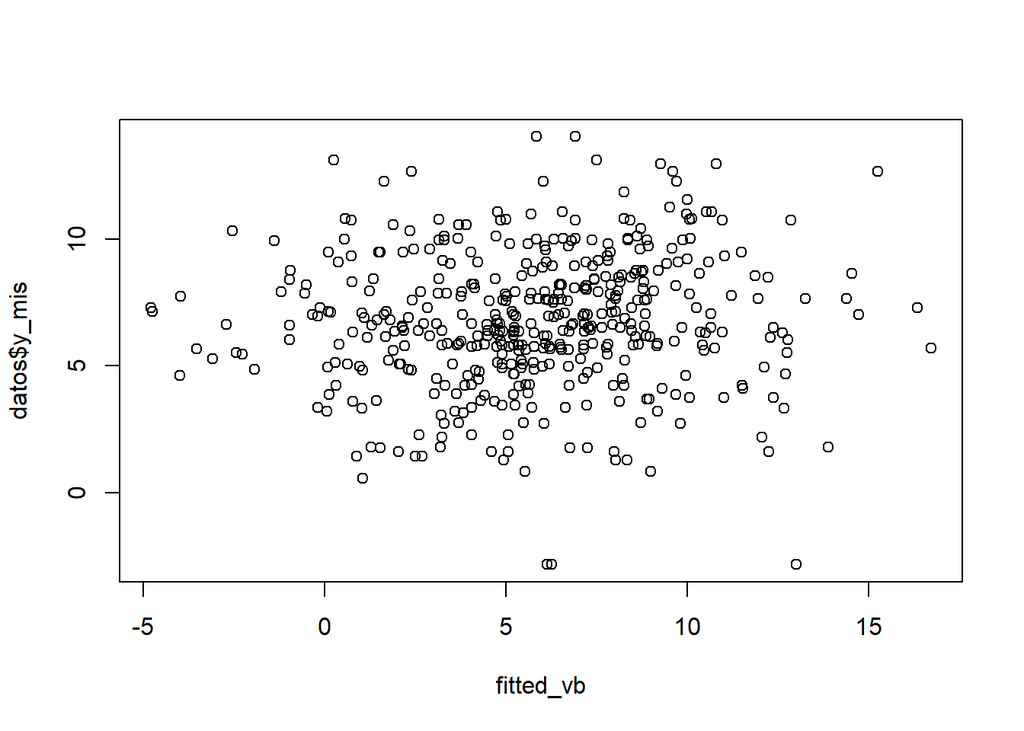

```r
fitted_vb <- apply(fit_vb$draws('y_mis'), 2, mean)
plot(fitted_vb, datos$y_mis)
```

# Alternativa (2) pooling unico mu

- Se propone usar
  $$\begin{align}
  \mu &\sim N_{M}(\mu_{0}1_{M}, \sigma^2_{\mu}I_{M}) \\
  \mu_{0} &\sim N(0, 10^2) \\
  \sigma^2_{\mu} &\sim InvGamma(0.001, 0.001),
  \end{align}$$

*Se observa que la estimación o efecto de cada $\mu_{i}$ es casi idéntico, por lo que quizás convenga hacer $M=1$, es decir, un único efecto.

```r
stan_code_pool_oneInt <- '
data {
  int<lower=1> K;  // regions
  int<lower=0> N_obs; // no. of observed y_{ij}
  int<lower=0> N_mis; // no. of missing  y_{ij}
  array[N_obs] int<lower=1, upper=K> group; // region of observed
  array[N_mis] int<lower=1, upper=K> groupmis; // region of missing
  int<lower=1> p;  // predictors
  vector[N_obs] y_obs;
  matrix[N_obs, p] X_obs;
  matrix[N_mis, p] X_mis;
}
parameters {
  vector<lower=0, upper=1>[K] rho;
  real<lower=0> sigma;           // sd for all region
  //vector[K] mu;                // intercept for each region
  real mu_tilde;            // intercept for each region
  real mu0;                    // global mean for mu
  real<lower=0> sigma_mu;        // sd for mu
  vector[p] beta;                // Regression coefficients
  vector<lower=0>[K] z_tilde;    // Latent variable for each group
  vector[N_mis] y_mis;           // missing y_{ij}
}
transformed parameters{
  real mu = mu0 + sigma_mu * mu_tilde;
  vector<lower=0>[K] z = z_tilde .* sigma ./ sqrt(1 - 2*square(rho)/pi());
}
model {
  target += sum( 0.5 * log1p(square(rho)) - log1m(square(rho)) );
  //lambda ~ normal(mu_lambda, sigma_lambda);
  //lambda_tilde ~ normal(0, 1);
  //mu_lambda ~ normal(0, 1);
  //sigma_lambda ~ normal(0, 1);
  sigma ~ inv_gamma(0.001, 0.001);
  //mu ~ normal(0, 10);
  mu_tilde ~ normal(0, 1);
  mu0 ~ normal(0, 10);
  sigma_mu ~ inv_gamma(0.001, 0.001);
  z_tilde ~ normal(0, 1);
  beta ~ normal(0, 10);
  vector[N_obs] sig = sigma * sqrt(1 - square(rho[group])) ./ sqrt(1 - 2/pi() * square(rho[group]));
  vector[N_obs] intercept = rho[group].* z[group] - sigma*rho[group] .* sqrt(2/pi()) ./ sqrt(1 - 2/pi() * square(rho[group]));
  target +=normal_id_glm_lupdf(y_obs | X_obs, mu + intercept, beta, sig);
  vector[N_mis] sigmis = sigma * sqrt(1 - square(rho[groupmis]))./ sqrt(1 - 2/pi() * square(rho[groupmis]));
  vector[N_mis] interceptmis = rho[groupmis] .* z[groupmis]- sigma*rho[groupmis] .* sqrt(2/pi()) ./ sqrt(1 - 2/pi() * square(rho[groupmis]));
  target +=normal_id_glm_lupdf(y_mis | X_mis, mu + interceptmis, beta, sigmis);
}'
```

```r
stan_model_pool_oneInt <- write_stan_file(stan_code_pool_oneInt) # write .stan file
mod_pool_oneInt <- cmdstan_model(stan_model_pool_oneInt, compile=T)
```

## Preparar datos

- Se considera perder todas las observaciones de la región dos

```r
datos <- get_sim(out=c(2, 3), prop=0.5)
dat <- list(
  K = datos$K,
  N_obs = datos$N_obs, # observed
  N_mis = datos$N_mis, # missing
  p = datos$p,
  y_obs = datos$y_obs,
  X_obs =  datos$X_obs,
  X_mis =  datos$X_mis,
  group = datos$group,
  groupmis = datos$groupmis
)

tmp <- data.frame(y=datos$y_obs, datos$X_obs)
r1 <- lm(y~ . , data=tmp)

set.seed(2)
init_list <- list(
  beta = coef(r1)[-1],
  sigma=1,
  rho = c(0.5, 0.5, 0.5, 0.5),
  mu_tilde=0,
  mu0 = 5,
  sigma_mu = 2,
  z_tilde=c(0.3, 0.3, 0.3, 0.3),
  y_mis = predict(r1, newdata = data.frame(datos$X_mis))
)
```

## Ajuste con VB

- Dejando que `eta`, un parámetro involucrado en el tamaño de paso en el ascenso del gradiente, sea buscado por `Stan`

```r
 apply(fit_vb2$draws('rho'), 2, mean)
```

```
##    rho[1]    rho[2]    rho[3]    rho[4]
## 0.9999526 0.1549535 0.1583673 0.9998049
```

```r
datos$rho
```

```
## [1] 0.5 0.7 0.8 0.9
```

```r
apply(fit_vb2$draws('mu'), 2, mean)
```

```
##       mu
## 6.371879
```

```r
datos$mu
```

```
## [1] 6.0 7.0 6.5 5.0
```

```r
apply(fit_vb2$draws('sigma'), 2, mean)
```

```
##    sigma
## 96.58332
```

```r
datos$sigma
```

```
## [1] 1.5
```

```r
apply(fit_vb2$draws('mu0'), 2, mean)
```

```
##      mu0
## 6.371605
```

```r
apply(fit_vb2$draws('sigma_mu'), 2, mean)
```

```
##   sigma_mu
## 0.04171856
```

```r
apply(fit_vb2$draws('beta'), 2, mean)
```

```
##     beta[1]     beta[2]     beta[3]     beta[4]     beta[5]
##  1.74515832  0.82085824 -1.21332788  0.12126996 -0.02937195
```

```r
datos$b
```

```
## [1]  1.9  0.8 -1.4  0.0  0.0
```

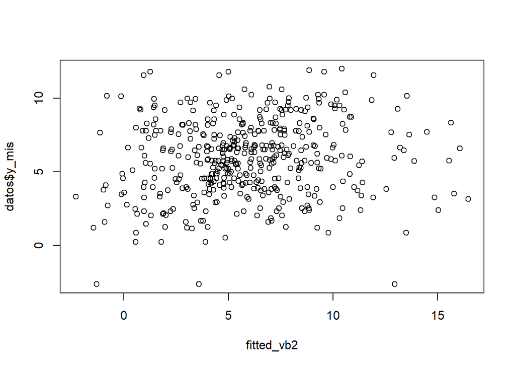

```r
fitted_vb2 <- apply(fit_vb2$draws('y_mis'), 2, mean)
plot(fitted_vb2, datos$y_mis)
```

# Alternativa (3) pooling lambda

- Se propone usar
  $$\begin{align}
  \mu &\sim N_{M}(\mu_{0}1_{M}, \sigma^2_{\mu}I_{M}) \\
  \mu_{0} &\sim N(0, 10^2) \\
  \sigma^2_{\mu} &\sim InvGamma(0.001, 0.001),
  \end{align}$$

*Se observa que la estimación o efecto de cada $\mu_{i}$ es casi idéntico, por lo que quizás convenga hacer $M=1$, es decir, un único efecto.

```r
stan_code_pool_oneInt2 <- '
data {
  int<lower=1> K;  // regions
  int<lower=0> N_obs; // no. of observed y_{ij}
  int<lower=0> N_mis; // no. of missing  y_{ij}
  array[N_obs] int<lower=1, upper=K> group; // region of observed
  array[N_mis] int<lower=1, upper=K> groupmis; // region of missing
  int<lower=1> p;  // predictors
  vector[N_obs] y_obs;
  matrix[N_obs, p] X_obs;
  matrix[N_mis, p] X_mis;
}
parameters {
  vector<lower=0>[K] lambda;
  real<lower=0> sigma;           // sd for all region
  real mu;            // intercept for each region
  vector[p] beta;                // Regression coefficients
  vector<lower=0>[K] z_tilde;    // Latent variable for each group
  vector[N_mis] y_mis;           // missing y_{ij}
}
transformed parameters{
  vector<lower=0, upper=1>[K] rho = lambda ./ sqrt(1 + square(lambda));
  //real mu = mu0 + sigma_mu * mu_tilde;
  vector<lower=0>[K] z = z_tilde .* sigma ./ sqrt(1 - 2*square(rho)/pi());
}
model {
  //target += sum( 0.5 * log1p(square(rho)) - log1m(square(rho)) );
  lambda ~ normal(0, 10);
  //lambda ~ normal(mu_lambda, sigma_lambda);
  //lambda_tilde ~ normal(0, 1);
  //mu_lambda ~ normal(0, 1);
  //sigma_lambda ~ normal(0, 1);
  sigma ~ inv_gamma(0.001, 0.001);
  mu ~ normal(0, 10);
  //mu_tilde ~ normal(0, 1);
  //mu0 ~ normal(0, 10);
  //sigma_mu ~ inv_gamma(0.001, 0.001);
  z_tilde ~ normal(0, 1);
  beta ~ normal(0, 10);
  vector[N_obs] sig = sigma * sqrt(1 - square(rho[group])) ./ sqrt(1 - 2/pi() * square(rho[group]));
  vector[N_obs] intercept = rho[group].* z[group] - sigma*rho[group] .* sqrt(2/pi()) ./ sqrt(1 - 2/pi() * square(rho[group]));
  target +=normal_id_glm_lupdf(y_obs | X_obs, mu + intercept, beta, sig);
  vector[N_mis] sigmis = sigma * sqrt(1 - square(rho[groupmis]))./ sqrt(1 - 2/pi() * square(rho[groupmis]));
  vector[N_mis] interceptmis = rho[groupmis] .* z[groupmis]- sigma*rho[groupmis] .* sqrt(2/pi()) ./ sqrt(1 - 2/pi() * square(rho[groupmis]));
  target +=normal_id_glm_lupdf(y_mis | X_mis, mu + interceptmis, beta, sigmis);
}'
```

```r
stan_model_pool_oneInt2 <- write_stan_file(stan_code_pool_oneInt2) # write .stan file
mod_pool_oneInt2 <- cmdstan_model(stan_model_pool_oneInt2, compile=T)
```

## Preparar datos

- Se considera perder todas las observaciones de la región dos

```r
datos <- get_sim(out=c(2, 3), prop=0.5)
dat <- list(
  K = datos$K,
  N_obs = datos$N_obs, # observed
  N_mis = datos$N_mis, # missing
  p = datos$p,
  y_obs = datos$y_obs,
  X_obs =  datos$X_obs,
  X_mis =  datos$X_mis,
  group = datos$group,
  groupmis = datos$groupmis
)

tmp <- data.frame(y=datos$y_obs, datos$X_obs)
r1 <- lm(y~ . , data=tmp)

set.seed(2)
init_list <- list(
  beta = coef(r1)[-1],
  sigma=1,
  lambda=c(1, 1, 1, 1),
  mu=6,
  z_tilde=c(0.3, 0.3, 0.3, 0.3),
  y_mis = predict(r1, newdata = data.frame(datos$X_mis))
)
```

## Ajuste con VB

- Dejando que `eta`, un parámetro involucrado en el tamaño de paso en el ascenso del gradiente, sea buscado por `Stan`

```r
apply(fit_vb3$draws('rho'), 2, mean)
```

```
##    rho[1]    rho[2]    rho[3]    rho[4]
## 0.9996762 0.1628253 0.1547955 0.9986264
```

```r
datos$rho
```

```
## [1] 0.5 0.7 0.8 0.9
```

```r
apply(fit_vb3$draws('mu'), 2, mean)
```

```
##       mu
## 6.314196
```

```r
datos$mu
```

```
## [1] 6.0 7.0 6.5 5.0
```

```r
apply(fit_vb3$draws('sigma'), 2, mean)
```

```
##    sigma
## 38.81324
```

```r
datos$sigma
```

```
## [1] 1.5
```

```r
apply(fit_vb3$draws('beta'), 2, mean)
```

```
##     beta[1]     beta[2]     beta[3]     beta[4]     beta[5]
##  1.70705578  0.78354951 -1.21418735  0.16642916 -0.04996062
```

```r
datos$b
```

```
## [1]  1.9  0.8 -1.4  0.0  0.0
```

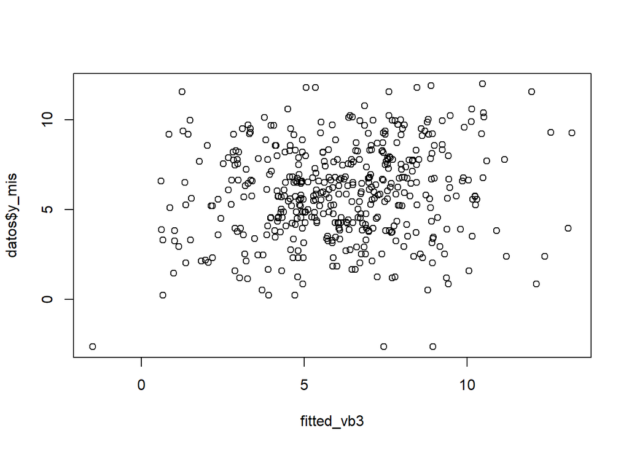

```r
fitted_vb3 <- apply(fit_vb3$draws('y_mis'), 2, mean)
plot(fitted_vb3, datos$y_mis)
```

# Alternativa (4) pooling lambda jerarquico

- Se propone usar
  $$\begin{align}
  \mu &\sim N_{M}(\mu_{0}1_{M}, \sigma^2_{\mu}I_{M}) \\
  \mu_{0} &\sim N(0, 10^2) \\
  \sigma^2_{\mu} &\sim InvGamma(0.001, 0.001),
  \end{align}$$

*Se observa que la estimación o efecto de cada $\mu_{i}$ es casi idéntico, por lo que quizás convenga hacer $M=1$, es decir, un único efecto.

```r
stan_code_pool_oneInt3 <- '
data {
  int<lower=1> K;  // regions
  int<lower=0> N_obs; // no. of observed y_{ij}
  int<lower=0> N_mis; // no. of missing  y_{ij}
  array[N_obs] int<lower=1, upper=K> group; // region of observed
  array[N_mis] int<lower=1, upper=K> groupmis; // region of missing
  int<lower=1> p;  // predictors
  vector[N_obs] y_obs;
  matrix[N_obs, p] X_obs;
  matrix[N_mis, p] X_mis;
}
parameters {
  vector<lower=0>[K] lambda;
  real mu_lambda;
  real<lower=0> sigma_lambda;
  real<lower=0> sigma;           // sd for all region
  real mu;            // intercept for each region
  vector[p] beta;                // Regression coefficients
  vector<lower=0>[K] z_tilde;    // Latent variable for each group
  vector[N_mis] y_mis;           // missing y_{ij}
}
transformed parameters{
  vector<lower=0, upper=1>[K] rho = lambda ./ sqrt(1 + square(lambda));
  //real mu = mu0 + sigma_mu * mu_tilde;
  vector<lower=0>[K] z = z_tilde .* sigma ./ sqrt(1 - 2*square(rho)/pi());
}
model {
  //target += sum( 0.5 * log1p(square(rho)) - log1m(square(rho)) );
  //lambda ~ normal(0, 10);
  lambda ~ normal(mu_lambda, sigma_lambda);
  //lambda_tilde ~ normal(0, 1);
  mu_lambda ~ normal(0, 10);
  sigma_lambda ~ inv_gamma(0.001, 0.001);
  sigma ~ inv_gamma(0.001, 0.001);
  mu ~ normal(0, 10);
  //mu_tilde ~ normal(0, 1);
  //mu0 ~ normal(0, 10);
  //sigma_mu ~ inv_gamma(0.001, 0.001);
  z_tilde ~ normal(0, 1);
  beta ~ normal(0, 10);
  vector[N_obs] sig = sigma * sqrt(1 - square(rho[group])) ./ sqrt(1 - 2/pi() * square(rho[group]));
  vector[N_obs] intercept = rho[group].* z[group] - sigma*rho[group] .* sqrt(2/pi()) ./ sqrt(1 - 2/pi() * square(rho[group]));
  target +=normal_id_glm_lupdf(y_obs | X_obs, mu + intercept, beta, sig);
  vector[N_mis] sigmis = sigma * sqrt(1 - square(rho[groupmis]))./ sqrt(1 - 2/pi() * square(rho[groupmis]));
  vector[N_mis] interceptmis = rho[groupmis] .* z[groupmis]- sigma*rho[groupmis] .* sqrt(2/pi()) ./ sqrt(1 - 2/pi() * square(rho[groupmis]));
  target +=normal_id_glm_lupdf(y_mis | X_mis, mu + interceptmis, beta, sigmis);
}'
```

```r
stan_model_pool_oneInt3 <- write_stan_file(stan_code_pool_oneInt3) # write .stan file
mod_pool_oneInt3 <- cmdstan_model(stan_model_pool_oneInt3, compile=T)
```

## Preparar datos

- Se considera perder todas las observaciones de la región dos

```r
datos <- get_sim(out=c(2, 3), prop=0.5)
dat <- list(
  K = datos$K,
  N_obs = datos$N_obs, # observed
  N_mis = datos$N_mis, # missing
  p = datos$p,
  y_obs = datos$y_obs,
  X_obs =  datos$X_obs,
  X_mis =  datos$X_mis,
  group = datos$group,
  groupmis = datos$groupmis
)

tmp <- data.frame(y=datos$y_obs, datos$X_obs)
r1 <- lm(y~ . , data=tmp)

set.seed(2)
init_list <- list(
  beta = coef(r1)[-1],
  sigma=1,
  lambda=c(1, 1, 1, 1),
  mu_lambda=1,
  sigma_lambda=0.5,
  mu=6,
  z_tilde=c(0.3, 0.3, 0.3, 0.3),
  y_mis = predict(r1, newdata = data.frame(datos$X_mis))
)
```

## Ajuste con VB

- Dejando que `eta`, un parámetro involucrado en el tamaño de paso en el ascenso del gradiente, sea buscado por `Stan`

```r
apply(fit_vb4$draws('rho'), 2, mean)
```

```
##    rho[1]    rho[2]    rho[3]    rho[4]
## 0.9431271 0.2069360 0.2168233 0.2248225
```

```r
datos$rho
```

```
## [1] 0.5 0.7 0.8 0.9
```

```r
apply(fit_vb4$draws('mu_lambda'), 2, mean)
```

```
## mu_lambda
## 0.8949634
```

```r
apply(fit_vb4$draws('sigma_lambda'), 2, mean)
```

```
## sigma_lambda
##     1.526653
```

```r
apply(fit_vb4$draws('mu'), 2, mean)
```

```
##       mu
## 6.109637
```

```r
datos$mu
```

```
## [1] 6.0 7.0 6.5 5.0
```

```r
apply(fit_vb4$draws('sigma'), 2, mean)
```

```
##    sigma
## 3.027921
```

```r
datos$sigma
```

```
## [1] 1.5
```

```r
apply(fit_vb4$draws('beta'), 2, mean)
```

```
##     beta[1]     beta[2]     beta[3]     beta[4]     beta[5]
##  1.46865400  0.84797463 -1.01263169  0.14876992 -0.08541746
```

```r
datos$b
```

```
## [1]  1.9  0.8 -1.4  0.0  0.0
```

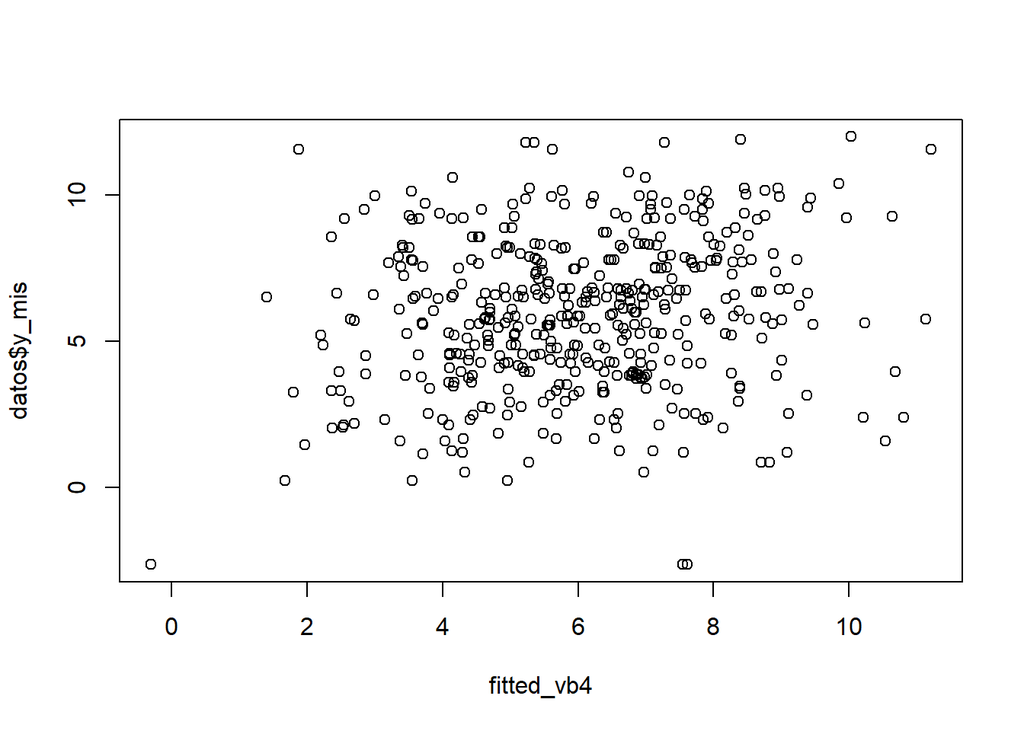

```r
fitted_vb4 <- apply(fit_vb4$draws('y_mis'), 2, mean)
plot(fitted_vb4, datos$y_mis)
```

# Alternativa (5) pooling lambda jerarquico + pooling unico mu

- Se propone usar
  $$\begin{align}
  \mu &\sim N_{M}(\mu_{0}1_{M}, \sigma^2_{\mu}I_{M}) \\
  \mu_{0} &\sim N(0, 10^2) \\
  \sigma^2_{\mu} &\sim InvGamma(0.001, 0.001),
  \end{align}$$

*Se observa que la estimación o efecto de cada $\mu_{i}$ es casi idéntico, por lo que quizás convenga hacer $M=1$, es decir, un único efecto.

```r
stan_code_pool_oneInt4 <- '
data {
  int<lower=1> K;  // regions
  int<lower=0> N_obs; // no. of observed y_{ij}
  int<lower=0> N_mis; // no. of missing  y_{ij}
  array[N_obs] int<lower=1, upper=K> group; // region of observed
  array[N_mis] int<lower=1, upper=K> groupmis; // region of missing
  int<lower=1> p;  // predictors
  vector[N_obs] y_obs;
  matrix[N_obs, p] X_obs;
  matrix[N_mis, p] X_mis;
}
parameters {
  vector<lower=0>[K] lambda;
  real mu_lambda;
  real<lower=0> sigma_lambda;
  real<lower=0> sigma;           // sd for all region
  real mu;            // intercept for each region
  real mu0;
  real<lower=0> sigma_mu;
  vector[p] beta;                // Regression coefficients
  vector<lower=0>[K] z_tilde;    // Latent variable for each group
  vector[N_mis] y_mis;           // missing y_{ij}
}
transformed parameters{
  vector<lower=0, upper=1>[K] rho = lambda ./ sqrt(1 + square(lambda));
  //real mu = mu0 + sigma_mu * mu_tilde;
  vector<lower=0>[K] z = z_tilde .* sigma ./ sqrt(1 - 2*square(rho)/pi());
}
model {
  //target += sum( 0.5 * log1p(square(rho)) - log1m(square(rho)) );
  //lambda ~ normal(0, 10);
  lambda ~ normal(mu_lambda, sigma_lambda);
  //lambda_tilde ~ normal(0, 1);
  mu_lambda ~ normal(0, 10);
  sigma_lambda ~ inv_gamma(0.001, 0.001);
  sigma ~ inv_gamma(0.001, 0.001);
  mu ~ normal(mu0, sigma_mu);
  //mu_tilde ~ normal(0, 1);
  mu0 ~ normal(0, 10);
  sigma_mu ~ inv_gamma(0.001, 0.001);
  z_tilde ~ normal(0, 1);
  beta ~ normal(0, 10);
  vector[N_obs] sig = sigma * sqrt(1 - square(rho[group])) ./ sqrt(1 - 2/pi() * square(rho[group]));
  vector[N_obs] intercept = rho[group].* z[group] - sigma*rho[group] .* sqrt(2/pi()) ./ sqrt(1 - 2/pi() * square(rho[group]));
  target +=normal_id_glm_lupdf(y_obs | X_obs, mu + intercept, beta, sig);
  vector[N_mis] sigmis = sigma * sqrt(1 - square(rho[groupmis]))./ sqrt(1 - 2/pi() * square(rho[groupmis]));
  vector[N_mis] interceptmis = rho[groupmis] .* z[groupmis]- sigma*rho[groupmis] .* sqrt(2/pi()) ./ sqrt(1 - 2/pi() * square(rho[groupmis]));
  target +=normal_id_glm_lupdf(y_mis | X_mis, mu + interceptmis, beta, sigmis);
}'
```

```r
stan_model_pool_oneInt4 <- write_stan_file(stan_code_pool_oneInt4) # write .stan file
mod_pool_oneInt4 <- cmdstan_model(stan_model_pool_oneInt4, compile=T)
```

## Preparar datos

- Se considera perder todas las observaciones de la región dos

```r
datos <- get_sim(out=c(2, 3), prop=0.5)
dat <- list(
  K = datos$K,
  N_obs = datos$N_obs, # observed
  N_mis = datos$N_mis, # missing
  p = datos$p,
  y_obs = datos$y_obs,
  X_obs =  datos$X_obs,
  X_mis =  datos$X_mis,
  group = datos$group,
  groupmis = datos$groupmis
)

tmp <- data.frame(y=datos$y_obs, datos$X_obs)
r1 <- lm(y~ . , data=tmp)

set.seed(2)
init_list <- list(
  beta = coef(r1)[-1],
  sigma=1,
  lambda=c(1, 1, 1, 1),
  mu_lambda=1,
  sigma_lambda=0.5,
  mu=6,
  mu0=6,
  sigma_mu=0.5,
  z_tilde=c(0.3, 0.3, 0.3, 0.3),
  y_mis = predict(r1, newdata = data.frame(datos$X_mis))
)
```

## Ajuste con VB

- Dejando que `eta`, un parámetro involucrado en el tamaño de paso en el ascenso del gradiente, sea buscado por `Stan`

```r
apply(fit_vb5$draws('rho'), 2, mean)
```

```
##    rho[1]    rho[2]    rho[3]    rho[4]
## 0.1226448 0.1029220 0.1126091 0.1125191
```

```r
datos$rho
```

```
## [1] 0.5 0.7 0.8 0.9
```

```r
apply(fit_vb5$draws('mu_lambda'), 2, mean)
```

```
## mu_lambda
## 0.1145103
```

```r
apply(fit_vb5$draws('sigma_lambda'), 2, mean)
```

```
## sigma_lambda
##    0.1068032
```

```r
apply(fit_vb5$draws('mu'), 2, mean)
```

```
##       mu
## 6.063268
```

```r
datos$mu
```

```
## [1] 6.0 7.0 6.5 5.0
```

```r
apply(fit_vb5$draws('mu0'), 2, mean)
```

```
##      mu0
## 6.047556
```

```r
apply(fit_vb5$draws('sigma_mu'), 2, mean)
```

```
## sigma_mu
## 3.917869
```

```r
apply(fit_vb5$draws('sigma'), 2, mean)
```

```
##    sigma
## 2.314544
```

```r
datos$sigma
```

```
## [1] 1.5
```

```r
apply(fit_vb5$draws('beta'), 2, mean)
```

```
##     beta[1]     beta[2]     beta[3]     beta[4]     beta[5]
##  1.26640573  0.79849359 -0.82646660  0.17131708 -0.05473838
```

```r
datos$b
```

```
## [1]  1.9  0.8 -1.4  0.0  0.0
```

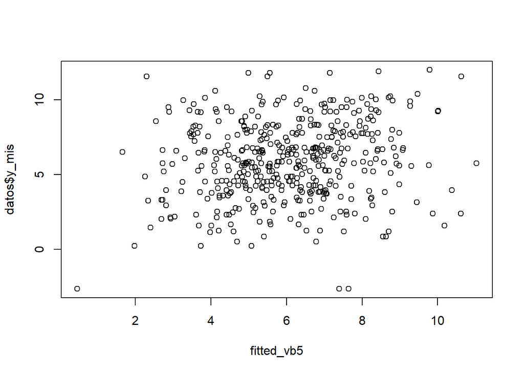

```r
fitted_vb5 <- apply(fit_vb5$draws('y_mis'), 2, mean)
plot(fitted_vb5, datos$y_mis)
```

# Comparacion

```r
metrics(fitted_vb, datos$y_mis)
```

```
##      Corr.        MAE       RMSE       MAPE
## 0.03985227 3.49787332 4.37101696 0.94500687
```

```r
metrics(fitted_vb2, datos$y_mis)
```

```
##    Corr.      MAE     RMSE     MAPE
## 0.124352 2.962988 3.966576 0.732252
```

```r
metrics(fitted_vb3, datos$y_mis)
```

```
##     Corr.       MAE      RMSE      MAPE
## 0.1391254 2.5016564 3.2913286 0.7110557
```

```r
metrics(fitted_vb4, datos$y_mis) # parece que va bien
```

```
##     Corr.       MAE      RMSE      MAPE
## 0.1669578 2.2400512 2.9379987 0.6525324
```

```r
metrics(fitted_vb5, datos$y_mis) # parece que va bien
```

```
##     Corr.       MAE      RMSE      MAPE
## 0.1580815 2.2153574 2.8917975 0.6545520
```